# report

### CA0 AI

## Importing Libraries

```python
import numpy as np
import pandas as pd
```

## Raed Dataframe

read train.csv and save dataframe in passengers

```python
passengers = pd.read_csv("train.csv")
```

```python
passengers.head()
```

|  | PassengerId | Survived | Pclass | Name | Sex | Age | SibSp | Parch | Ticket | Fare | Cabin | Embarked |
| --- | --- | --- | --- | --- | --- | --- | --- | --- | --- | --- | --- | --- |
| 0 | 1 | 0 | 3 | Braund, Mr. Owen Harris | male | 22.0 | 1 | 0 | A/5 21171 | 7.2500 | NaN | S |
| 1 | 2 | 1 | 1 | Cumings, Mrs. John Bradley (Florence Briggs Th... | female | 38.0 | 1 | 0 | PC 17599 | 71.2833 | C85 | C |
| 2 | 3 | 1 | 3 | Heikkinen, Miss. Laina | female | 26.0 | 0 | 0 | STON/O2. 3101282 | 7.9250 | NaN | S |
| 3 | 4 | 1 | 1 | Futrelle, Mrs. Jacques Heath (Lily May Peel) | female | 35.0 | 1 | 0 | 113803 | 53.1000 | C123 | S |
| 4 | 5 | 0 | 3 | Allen, Mr. William Henry | male | 35.0 | 0 | 0 | 373450 | 8.0500 | NaN | S |

```python
passengers.tail(10)
```

|  | PassengerId | Survived | Pclass | Name | Sex | Age | SibSp | Parch | Ticket | Fare | Cabin | Embarked |
| --- | --- | --- | --- | --- | --- | --- | --- | --- | --- | --- | --- | --- |
| 881 | 882 | 0 | 3 | Markun, Mr. Johann | male | 33.0 | 0 | 0 | 349257 | 7.8958 | NaN | S |
| 882 | 883 | 0 | 3 | Dahlberg, Miss. Gerda Ulrika | female | 22.0 | 0 | 0 | 7552 | 10.5167 | NaN | S |
| 883 | 884 | 0 | 2 | Banfield, Mr. Frederick James | male | 28.0 | 0 | 0 | C.A./SOTON 34068 | 10.5000 | NaN | S |
| 884 | 885 | 0 | 3 | Sutehall, Mr. Henry Jr | male | 25.0 | 0 | 0 | SOTON/OQ 392076 | 7.0500 | NaN | S |
| 885 | 886 | 0 | 3 | Rice, Mrs. William (Margaret Norton) | female | 39.0 | 0 | 5 | 382652 | 29.1250 | NaN | Q |
| 886 | 887 | 0 | 2 | Montvila, Rev. Juozas | male | 27.0 | 0 | 0 | 211536 | 13.0000 | NaN | S |
| 887 | 888 | 1 | 1 | Graham, Miss. Margaret Edith | female | 19.0 | 0 | 0 | 112053 | 30.0000 | B42 | S |
| 888 | 889 | 0 | 3 | Johnston, Miss. Catherine Helen "Carrie" | female | NaN | 1 | 2 | W./C. 6607 | 23.4500 | NaN | S |
| 889 | 890 | 1 | 1 | Behr, Mr. Karl Howell | male | 26.0 | 0 | 0 | 111369 | 30.0000 | C148 | C |
| 890 | 891 | 0 | 3 | Dooley, Mr. Patrick | male | 32.0 | 0 | 0 | 370376 | 7.7500 | NaN | Q |

by using **describe** we can find statical info about our dataframe like min, max, mean, std, ...

```python
passengers.describe()
```

|  | PassengerId | Survived | Pclass | Age | SibSp | Parch | Fare |
| --- | --- | --- | --- | --- | --- | --- | --- |
| count | 891.000000 | 891.000000 | 891.000000 | 714.000000 | 891.000000 | 891.000000 | 891.000000 |
| mean | 446.000000 | 0.383838 | 2.308642 | 29.699118 | 0.523008 | 0.381594 | 32.204208 |
| std | 257.353842 | 0.486592 | 0.836071 | 14.526497 | 1.102743 | 0.806057 | 49.693429 |
| min | 1.000000 | 0.000000 | 1.000000 | 0.420000 | 0.000000 | 0.000000 | 0.000000 |
| 25% | 223.500000 | 0.000000 | 2.000000 | 20.125000 | 0.000000 | 0.000000 | 7.910400 |
| 50% | 446.000000 | 0.000000 | 3.000000 | 28.000000 | 0.000000 | 0.000000 | 14.454200 |
| 75% | 668.500000 | 1.000000 | 3.000000 | 38.000000 | 1.000000 | 0.000000 | 31.000000 |
| max | 891.000000 | 1.000000 | 3.000000 | 80.000000 | 8.000000 | 6.000000 | 512.329200 |

## Info

**info** prints information about the DataFrame.

The information contains the number of columns, column labels, column data types, memory usage, range index, and the number of cells in each column (non-null values)

```python
passengers.info()
```

```
<class 'pandas.core.frame.DataFrame'>
RangeIndex: 891 entries, 0 to 890
Data columns (total 12 columns):
 #   Column       Non-Null Count  Dtype
---  ------       --------------  -----
 0   PassengerId  891 non-null    int64
 1   Survived     891 non-null    int64
 2   Pclass       891 non-null    int64
 3   Name         891 non-null    object
 4   Sex          891 non-null    object
 5   Age          714 non-null    float64
 6   SibSp        891 non-null    int64
 7   Parch        891 non-null    int64
 8   Ticket       891 non-null    object
 9   Fare         891 non-null    float64
 10  Cabin        204 non-null    object
 11  Embarked     889 non-null    object
dtypes: float64(2), int64(5), object(5)
memory usage: 83.7+ KB
```

## Constraints

```python
MEN = 0
WOMEN = 1
```

## Label Encoding

we can use **replace** for label encoding.

The replace() method searches the entire DataFrame and replaces every case of the specified value.

```python
passengers = passengers.replace(["male", "female"], [MEN, WOMEN])
passengers.head()
```

|  | PassengerId | Survived | Pclass | Name | Sex | Age | SibSp | Parch | Ticket | Fare | Cabin | Embarked |
| --- | --- | --- | --- | --- | --- | --- | --- | --- | --- | --- | --- | --- |
| 0 | 1 | 0 | 3 | Braund, Mr. Owen Harris | 0 | 22.0 | 1 | 0 | A/5 21171 | 7.2500 | NaN | S |
| 1 | 2 | 1 | 1 | Cumings, Mrs. John Bradley (Florence Briggs Th... | 1 | 38.0 | 1 | 0 | PC 17599 | 71.2833 | C85 | C |
| 2 | 3 | 1 | 3 | Heikkinen, Miss. Laina | 1 | 26.0 | 0 | 0 | STON/O2. 3101282 | 7.9250 | NaN | S |
| 3 | 4 | 1 | 1 | Futrelle, Mrs. Jacques Heath (Lily May Peel) | 1 | 35.0 | 1 | 0 | 113803 | 53.1000 | C123 | S |
| 4 | 5 | 0 | 3 | Allen, Mr. William Henry | 0 | 35.0 | 0 | 0 | 373450 | 8.0500 | NaN | S |

## counting NAN values

in order to coumt NAN values, we use two functions:

**isna()** which returns a boolean same-sized object indicating if the values are NA

**sum()** now if we find sum of *passangers.isna()* we can count number of missing values at each column.

```python
passengers.isna().sum()
```

```
PassengerId      0
Survived         0
Pclass           0
Name             0
Sex              0
Age            177
SibSp            0
Parch            0
Ticket           0
Fare             0
Cabin          687
Embarked         2
dtype: int64
```

## what to do with NAN values

```python
# replace NAN values with average age
passengers["Age"].fillna(passengers["Age"].mean(), inplace = True)

#there are two people we dont know thir embark place we just write C for it!
passengers["Embarked"].fillna("C", inplace = True)

# there are lotes of NAN values in "Cabin" so we delete it completly
passengers.drop("Cabin", axis = 1, inplace = True)

# PassengerId is diffrent  for all passengers, so it doesnt give us extra info and can be deleted
passengers.drop("PassengerId", axis = 1, inplace = True)

passengers.isna().sum()
```

```
Survived    0
Pclass      0
Name        0
Sex         0
Age         0
SibSp       0
Parch       0
Ticket      0
Fare        0
Embarked    0
dtype: int64
```

#### replacing NAN values with mean:

it is a simple soloution to replacing NAN values with mean and it works totally fine. but when missing values are more than expected, it can reduce std and variance a lot and our data wont be accurate anymore.

#### completly deleting column containing missing values:

by doing this we guarantee that robust and highly accurate dataset this methos is very usefull when that column doesnt give extra info for our furthur calculation and when missing values are a lot.

in other hand by deleting whole column, we are losing some data that is inevitible.

## count

#### MEN, WOMEN

```python
men = passengers[passengers.Sex == MEN]
women = passengers[passengers.Sex == WOMEN]
print(f"men num : {men.__len__()}")
print(f"women num : {women.__len__()}")
```

```
men num : 577
women num : 314
```

#### MEN from southampton

```python
men_from_southampton = men[men.Embarked == "S"]
print(f"men_from_southampton : {men_from_southampton.__len__()}")
men_from_southampton.head(15)
```

```
men_from_southampton : 441
```

|  | Survived | Pclass | Name | Sex | Age | SibSp | Parch | Ticket | Fare | Embarked |
| --- | --- | --- | --- | --- | --- | --- | --- | --- | --- | --- |
| 0 | 0 | 3 | Braund, Mr. Owen Harris | 0 | 22.000000 | 1 | 0 | A/5 21171 | 7.2500 | S |
| 4 | 0 | 3 | Allen, Mr. William Henry | 0 | 35.000000 | 0 | 0 | 373450 | 8.0500 | S |
| 6 | 0 | 1 | McCarthy, Mr. Timothy J | 0 | 54.000000 | 0 | 0 | 17463 | 51.8625 | S |
| 7 | 0 | 3 | Palsson, Master. Gosta Leonard | 0 | 2.000000 | 3 | 1 | 349909 | 21.0750 | S |
| 12 | 0 | 3 | Saundercock, Mr. William Henry | 0 | 20.000000 | 0 | 0 | A/5. 2151 | 8.0500 | S |
| 13 | 0 | 3 | Andersson, Mr. Anders Johan | 0 | 39.000000 | 1 | 5 | 347082 | 31.2750 | S |
| 17 | 1 | 2 | Williams, Mr. Charles Eugene | 0 | 29.699118 | 0 | 0 | 244373 | 13.0000 | S |
| 20 | 0 | 2 | Fynney, Mr. Joseph J | 0 | 35.000000 | 0 | 0 | 239865 | 26.0000 | S |
| 21 | 1 | 2 | Beesley, Mr. Lawrence | 0 | 34.000000 | 0 | 0 | 248698 | 13.0000 | S |
| 23 | 1 | 1 | Sloper, Mr. William Thompson | 0 | 28.000000 | 0 | 0 | 113788 | 35.5000 | S |
| 27 | 0 | 1 | Fortune, Mr. Charles Alexander | 0 | 19.000000 | 3 | 2 | 19950 | 263.0000 | S |
| 29 | 0 | 3 | Todoroff, Mr. Lalio | 0 | 29.699118 | 0 | 0 | 349216 | 7.8958 | S |
| 33 | 0 | 2 | Wheadon, Mr. Edward H | 0 | 66.000000 | 0 | 0 | C.A. 24579 | 10.5000 | S |
| 35 | 0 | 1 | Holverson, Mr. Alexander Oskar | 0 | 42.000000 | 1 | 0 | 113789 | 52.0000 | S |
| 37 | 0 | 3 | Cann, Mr. Ernest Charles | 0 | 21.000000 | 0 | 0 | A./5. 2152 | 8.0500 | S |

```python
passengers.head()
```

[output not shown]

#### retired passengers

```python
def is_retired(passengers) -> bool :
    return(
        (passengers.Age > 35) &
        (passengers.Pclass == 3) &
        (passengers.SibSp == 0) &
        (passengers.Parch == 0)
    )

retired_passengers = passengers[is_retired(passengers)]

print(f"retired_passengers : {retired_passengers.__len__()}")
retired_passengers.head(3)
```

```
retired_passengers : 41
```

|  | Survived | Pclass | Name | Sex | Age | SibSp | Parch | Ticket | Fare | Embarked |
| --- | --- | --- | --- | --- | --- | --- | --- | --- | --- | --- |
| 94 | 0 | 3 | Coxon, Mr. Daniel | 0 | 59.0 | 0 | 0 | 364500 | 7.2500 | S |
| 108 | 0 | 3 | Rekic, Mr. Tido | 0 | 38.0 | 0 | 0 | 349249 | 7.8958 | S |
| 116 | 0 | 3 | Connors, Mr. Patrick | 0 | 70.5 | 0 | 0 | 370369 | 7.7500 | Q |

## with/without vectorization

#### import to calculate delay time

```python
import time
```

#### with vectorization

```python
s_time = time.time()
queenstown_fare_mean = passengers[passengers.Embarked == "Q"]["Fare"].mean()
f_time = time.time()
print(f"exec time: {(f_time - s_time) * 1000} miliseconds")
print(f"queenstown_fare_mean : {queenstown_fare_mean}")

passengers.head()
```

```
exec time: 7.712602615356445 miliseconds
queenstown_fare_mean : 13.276029870129872
```

|  | Survived | Pclass | Name | Sex | Age | SibSp | Parch | Ticket | Fare | Embarked |
| --- | --- | --- | --- | --- | --- | --- | --- | --- | --- | --- |
| 0 | 0 | 3 | Braund, Mr. Owen Harris | 0 | 22.0 | 1 | 0 | A/5 21171 | 7.2500 | S |
| 1 | 1 | 1 | Cumings, Mrs. John Bradley (Florence Briggs Th... | 1 | 38.0 | 1 | 0 | PC 17599 | 71.2833 | C |
| 2 | 1 | 3 | Heikkinen, Miss. Laina | 1 | 26.0 | 0 | 0 | STON/O2. 3101282 | 7.9250 | S |
| 3 | 1 | 1 | Futrelle, Mrs. Jacques Heath (Lily May Peel) | 1 | 35.0 | 1 | 0 | 113803 | 53.1000 | S |
| 4 | 0 | 3 | Allen, Mr. William Henry | 0 | 35.0 | 0 | 0 | 373450 | 8.0500 | S |

#### without vectorization

```python
s_time = time.time()
sum = 0
num = 0
for index, row in passengers.iterrows():
    if row["Embarked"] == "Q":
        num += 1
        sum += row["Fare"]

queenstown_fare_mean = sum / num
f_time = time.time()
print(f"exec time: {(f_time - s_time) * 1000} miliseconds")
print(f"queenstown_fare_mean : {queenstown_fare_mean}")
passengers.head()
```

```
exec time: 233.02006721496582 miliseconds
queenstown_fare_mean : 13.276029870129872
```

|  | Survived | Pclass | Name | Sex | Age | SibSp | Parch | Ticket | Fare | Embarked |
| --- | --- | --- | --- | --- | --- | --- | --- | --- | --- | --- |
| 0 | 0 | 3 | Braund, Mr. Owen Harris | 0 | 22.0 | 1 | 0 | A/5 21171 | 7.2500 | S |
| 1 | 1 | 1 | Cumings, Mrs. John Bradley (Florence Briggs Th... | 1 | 38.0 | 1 | 0 | PC 17599 | 71.2833 | C |
| 2 | 1 | 3 | Heikkinen, Miss. Laina | 1 | 26.0 | 0 | 0 | STON/O2. 3101282 | 7.9250 | S |
| 3 | 1 | 1 | Futrelle, Mrs. Jacques Heath (Lily May Peel) | 1 | 35.0 | 1 | 0 | 113803 | 53.1000 | S |
| 4 | 0 | 3 | Allen, Mr. William Henry | 0 | 35.0 | 0 | 0 | 373450 | 8.0500 | S |

## Label encoding for Embarked

in order make most of our data, i decided to encode **"Embarked"** too

#### constraints

```python
CHERBOURGE = 0
QUEENSTOWN = 1
SOUTHAMPTON = 2
```

#### encode

```python
passengers["Embarked"].replace(["C", "Q", "S"], [CHERBOURGE, QUEENSTOWN, SOUTHAMPTON], inplace = True)
passengers
```

|  | Survived | Pclass | Name | Sex | Age | SibSp | Parch | Ticket | Fare | Embarked |
| --- | --- | --- | --- | --- | --- | --- | --- | --- | --- | --- |
| 0 | 0 | 3 | Braund, Mr. Owen Harris | 0 | 22.000000 | 1 | 0 | A/5 21171 | 7.2500 | 2 |
| 1 | 1 | 1 | Cumings, Mrs. John Bradley (Florence Briggs Th... | 1 | 38.000000 | 1 | 0 | PC 17599 | 71.2833 | 0 |
| 2 | 1 | 3 | Heikkinen, Miss. Laina | 1 | 26.000000 | 0 | 0 | STON/O2. 3101282 | 7.9250 | 2 |
| 3 | 1 | 1 | Futrelle, Mrs. Jacques Heath (Lily May Peel) | 1 | 35.000000 | 1 | 0 | 113803 | 53.1000 | 2 |
| 4 | 0 | 3 | Allen, Mr. William Henry | 0 | 35.000000 | 0 | 0 | 373450 | 8.0500 | 2 |
| ... | ... | ... | ... | ... | ... | ... | ... | ... | ... | ... |
| 886 | 0 | 2 | Montvila, Rev. Juozas | 0 | 27.000000 | 0 | 0 | 211536 | 13.0000 | 2 |
| 887 | 1 | 1 | Graham, Miss. Margaret Edith | 1 | 19.000000 | 0 | 0 | 112053 | 30.0000 | 2 |
| 888 | 0 | 3 | Johnston, Miss. Catherine Helen "Carrie" | 1 | 29.699118 | 1 | 2 | W./C. 6607 | 23.4500 | 2 |
| 889 | 1 | 1 | Behr, Mr. Karl Howell | 0 | 26.000000 | 0 | 0 | 111369 | 30.0000 | 0 |
| 890 | 0 | 3 | Dooley, Mr. Patrick | 0 | 32.000000 | 0 | 0 | 370376 | 7.7500 | 1 |

891 rows × 10 columns

## Hist

```
array([[<AxesSubplot: title={'center': 'Survived'}>,
        <AxesSubplot: title={'center': 'Pclass'}>,
        <AxesSubplot: title={'center': 'Sex'}>],
       [<AxesSubplot: title={'center': 'Age'}>,
        <AxesSubplot: title={'center': 'SibSp'}>,
        <AxesSubplot: title={'center': 'Parch'}>],
       [<AxesSubplot: title={'center': 'Fare'}>,
        <AxesSubplot: title={'center': 'Embarked'}>, <AxesSubplot: >]],
      dtype=object)
```

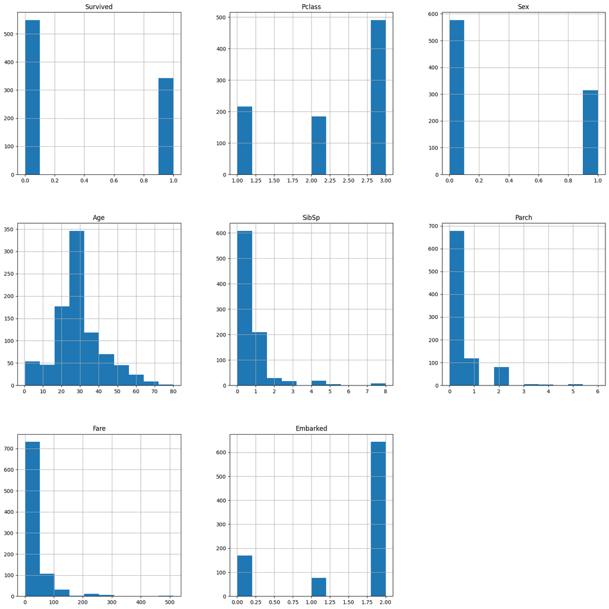

```python
import matplotlib.pyplot as plt
passengers.hist(figsize = (20, 20))
```

## Normalizing

```python
norm_passengers = (passengers - passengers.mean(numeric_only = True)) / passengers.std(numeric_only = True)
norm_passengers.head()
```

|  | Age | Embarked | Fare | Name | Parch | Pclass | Sex | SibSp | Survived | Ticket |
| --- | --- | --- | --- | --- | --- | --- | --- | --- | --- | --- |
| 0 | -0.592148 | 0.589044 | -0.502163 | NaN | -0.473408 | 0.826913 | -0.737281 | 0.432550 | -0.788829 | NaN |
| 1 | 0.638430 | -1.928165 | 0.786404 | NaN | -0.473408 | -1.565228 | 1.354813 | 0.432550 | 1.266279 | NaN |
| 2 | -0.284503 | 0.589044 | -0.488580 | NaN | -0.473408 | 0.826913 | 1.354813 | -0.474279 | 1.266279 | NaN |
| 3 | 0.407697 | 0.589044 | 0.420494 | NaN | -0.473408 | -1.565228 | 1.354813 | 0.432550 | 1.266279 | NaN |
| 4 | 0.407697 | 0.589044 | -0.486064 | NaN | -0.473408 | 0.826913 | -0.737281 | -0.474279 | -0.788829 | NaN |

## PDF of aliveness!

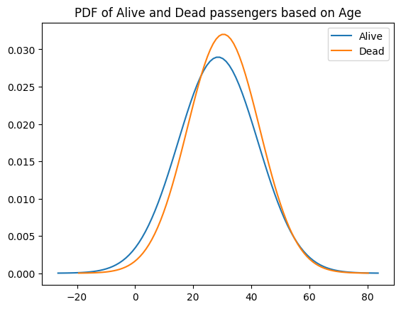

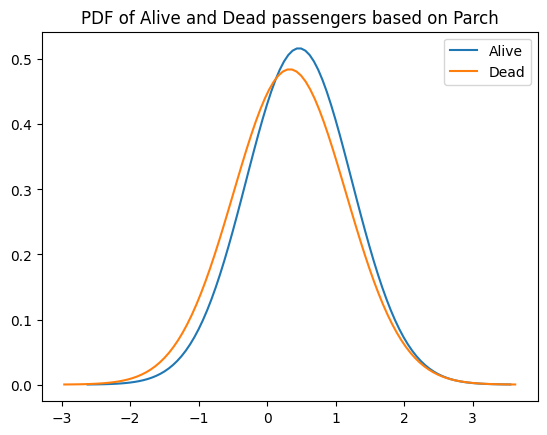

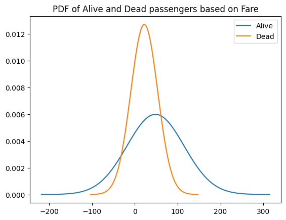

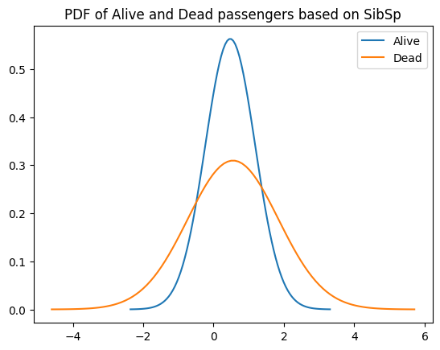

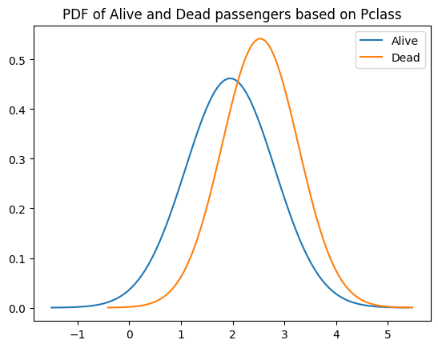

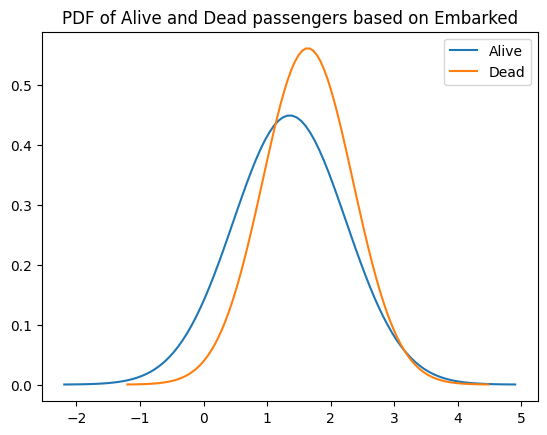

```python
from scipy.stats import norm
import matplotlib.pyplot as plt

PLOT_ZOOM = 4

def plot_(alive_atr, dead_atr, column):
    alive_mean = alive_atr.mean()
    alive_std = alive_atr.std()
    dead_mean = dead_atr.mean()
    dead_std = dead_atr.std()

    x = np.linspace(alive_mean - PLOT_ZOOM * alive_std, alive_mean + PLOT_ZOOM * alive_std, 100)
    plt.plot(x, norm.pdf(x, alive_mean, alive_std))

    x = np.linspace(dead_mean - PLOT_ZOOM * dead_std, dead_mean + PLOT_ZOOM * dead_std, 100)
    plt.plot(x, norm.pdf(x, dead_mean, dead_std))

    plt.legend(['Alive', 'Dead'])
    plt.title(f'PDF of Alive and Dead passengers based on {column}')
    plt.show()

alive_passengers = passengers[passengers.Survived == 1]
dead_passengers =  passengers[passengers.Survived == 0]

for column in ["Age", "Parch", "Fare", "SibSp", "Pclass", "Embarked"]:
    plot_(alive_passengers[column], dead_passengers[column], column)
```

## predict who is alive

#### chose attribute

in order to predict, we need to choose one of the attributes plotted above.

```python
chosen_atr = "Fare"
```

#### read test file

```python
new_passengers = pd.read_csv("test.csv")

alive_mean = alive_passengers[chosen_atr].mean()
alive_std = alive_passengers[chosen_atr].std()
dead_mean = dead_passengers[chosen_atr].mean()
dead_std = dead_passengers[chosen_atr].std()

print(f"alive_mean : {alive_mean}")
print(f"alive_std : {alive_std}")
print(f"dead_mean : {dead_mean}")
print(f"dead_std : {dead_std}")

def condition(t):
    if (t < alive_mean + 1/4*alive_std) and t > (alive_mean - 1/4*alive_std):
        return "Alive"

    if (t < dead_mean + 1/4*dead_std) and t > (dead_mean - 1/4*dead_std):
        return "Dead"

    if (abs(t - alive_mean) < abs(t - dead_mean)):
        return "Alive"
    return "Dead"

new_passengers["Alive"] = np.nan
new_passengers["Alive"] = new_passengers[chosen_atr].apply(condition)

new_passengers[["PassengerId","Alive"]].to_csv("prediction.txt")

new_passengers.head(20)
```

```
alive_mean : 48.39540760233918
alive_std : 66.59699811829475
dead_mean : 22.117886885245902
dead_std : 31.38820653056397
```

|  | PassengerId | Pclass | Name | Sex | Age | SibSp | Parch | Ticket | Fare | Cabin | Embarked | Alive |
| --- | --- | --- | --- | --- | --- | --- | --- | --- | --- | --- | --- | --- |
| 0 | 892 | 3 | Kelly, Mr. James | male | 34.5 | 0 | 0 | 330911 | 7.8292 | NaN | Q | Dead |
| 1 | 893 | 3 | Wilkes, Mrs. James (Ellen Needs) | female | 47.0 | 1 | 0 | 363272 | 7.0000 | NaN | S | Dead |
| 2 | 894 | 2 | Myles, Mr. Thomas Francis | male | 62.0 | 0 | 0 | 240276 | 9.6875 | NaN | Q | Dead |
| 3 | 895 | 3 | Wirz, Mr. Albert | male | 27.0 | 0 | 0 | 315154 | 8.6625 | NaN | S | Dead |
| 4 | 896 | 3 | Hirvonen, Mrs. Alexander (Helga E Lindqvist) | female | 22.0 | 1 | 1 | 3101298 | 12.2875 | NaN | S | Dead |
| 5 | 897 | 3 | Svensson, Mr. Johan Cervin | male | 14.0 | 0 | 0 | 7538 | 9.2250 | NaN | S | Dead |
| 6 | 898 | 3 | Connolly, Miss. Kate | female | 30.0 | 0 | 0 | 330972 | 7.6292 | NaN | Q | Dead |
| 7 | 899 | 2 | Caldwell, Mr. Albert Francis | male | 26.0 | 1 | 1 | 248738 | 29.0000 | NaN | S | Dead |
| 8 | 900 | 3 | Abrahim, Mrs. Joseph (Sophie Halaut Easu) | female | 18.0 | 0 | 0 | 2657 | 7.2292 | NaN | C | Dead |
| 9 | 901 | 3 | Davies, Mr. John Samuel | male | 21.0 | 2 | 0 | A/4 48871 | 24.1500 | NaN | S | Dead |
| 10 | 902 | 3 | Ilieff, Mr. Ylio | male | NaN | 0 | 0 | 349220 | 7.8958 | NaN | S | Dead |
| 11 | 903 | 1 | Jones, Mr. Charles Cresson | male | 46.0 | 0 | 0 | 694 | 26.0000 | NaN | S | Dead |
| 12 | 904 | 1 | Snyder, Mrs. John Pillsbury (Nelle Stevenson) | female | 23.0 | 1 | 0 | 21228 | 82.2667 | B45 | S | Alive |
| 13 | 905 | 2 | Howard, Mr. Benjamin | male | 63.0 | 1 | 0 | 24065 | 26.0000 | NaN | S | Dead |
| 14 | 906 | 1 | Chaffee, Mrs. Herbert Fuller (Carrie Constance... | female | 47.0 | 1 | 0 | W.E.P. 5734 | 61.1750 | E31 | S | Alive |
| 15 | 907 | 2 | del Carlo, Mrs. Sebastiano (Argenia Genovesi) | female | 24.0 | 1 | 0 | SC/PARIS 2167 | 27.7208 | NaN | C | Dead |
| 16 | 908 | 2 | Keane, Mr. Daniel | male | 35.0 | 0 | 0 | 233734 | 12.3500 | NaN | Q | Dead |
| 17 | 909 | 3 | Assaf, Mr. Gerios | male | 21.0 | 0 | 0 | 2692 | 7.2250 | NaN | C | Dead |
| 18 | 910 | 3 | Ilmakangas, Miss. Ida Livija | female | 27.0 | 1 | 0 | STON/O2. 3101270 | 7.9250 | NaN | S | Dead |
| 19 | 911 | 3 | Assaf Khalil, Mrs. Mariana (Miriam")" | female | 45.0 | 0 | 0 | 2696 | 7.2250 | NaN | C | Dead |